# Tutorial 5: Figure 3: Model evaluation

Wei-Chun Chou

June, 2020

# Introduction

This tutorial aims to guide you to step-by-step reproduce the results of Figure 3: Model evaluation results in rats. Comparisons of the model-predicted versus the observed PFOS levels in maternal plasma during (A) gestation (maternal dose was 0.1 mg/kg/day as an example) and (B) lactation (maternal dose was 0.4 mg/kg/day as an example) and (C) pup’s plasma in rats (maternal dose was 0.8 mg/kg/day as an example).

# Prerequisites

Before running your model, you should set up your working directory, compile the PBPK model, install all required packages and input needed datasets. The model file and datasets can be found in the additional files.

## Setting up your working directory

The working directory has to be changed to the **PlotCode** folder. You can use two ways to change your working directory as follow:

1. Use RStudio: use the menu to change your working directory under **Session > Set Working Directory > Choose Directory**.
2. Use R function: use the R function `setwd()` to change the path to your working directory.

## Loading required R package

The list of R packages should be installed prior to the simulation. If you have not installed these packages (listed below), please install these packages to your Rstudio using the R function `require (" ")` and then use `library` open it.

```r
##  Loading requried R packages
library(mrgsolve)    ## R-package for Loading mrgsolve code
library(magrittr)    ## R-package for the pipe, %>%
library(dplyr)       ## R-package for transform and summarize tabular data with rows and columns; %>%
library(tidyverse)   ## R-package for transform and summarize tabular data with rows and columns; %>%
library(ggplot2)     ## R-package for GGplot
library(FME)         ## R-package for model fitting
library(minpack.lm)  ## R-package for model fitting
library(gridExtra)   ## R-package for function "grid.arrange"
```

## Read mrgsolve-based PBPK Model R file

The pre-pregnant, gestational and lactational PBPK model were written in `RMod.R` and `HMod.R` file. Before compiling the model, please conduct/call this file using R function `source`.

```r
## Input mrgsolve-based PBPK Model
source (file = "RMod.R")  ## input the rat model for nonpregnnat, geatation and lactation
source (file = "HMod.R")  ## input the human model for nonpregnnat, geatation and lactation
```

## Complie mrgsolve-based PBPK Model

Read the code and build these mrgsolve-based PBPK models. You should make sure all models are built correctly.

```r
## Build mrgsolve-based PBPK Model
PreGmod_R <- mcode ("PreG_RatPBPK.code", PreG_RatPBPK.code)
```

```
## Building PreG_RatPBPK_code ... done.
```

```r
Gmod_R    <- mcode ("GRatPBPK.code", GRatPBPK.code)
```

```
## Building GRatPBPK_code ... done.
```

```r
Lmod_R    <- mcode ("LRatPBPK.code", LRatPBPK.code)
```

```
## Building LRatPBPK_code ... done.
```

```r
PreGmod_H <- mcode ("PreGHumanPBPK.code", PreGHumanPBPK.code)
```

```
## Building PreGHumanPBPK_code ... done.
```

```r
Gmod_H    <- mcode ("GHumanPBPK.code", GHumanPBPK.code)
```

```
## Building GHumanPBPK_code ... done.
```

```r
Lmod_H    <- mcode ("LHumanPBPK.code", LHumanPBPK.code)
```

```
## Building LHumanPBPK_code ... done.
```

## Loading datasets

In this step, you need to input the .csv file to the Rstudio. The function `read.csv` can be used to read the csv files into R

```r
RDat <- read.csv(file = "Data_R.csv")
HDat <- read.csv(file = "Data_H.csv")
```

## Loading Fit results from rds files to obtain final parameter values

```r
GFit_R <- readRDS(file = "GFit_R.rds")
LFit_R <- readRDS(file = "LFit_R.rds")
GFit_H <- readRDS(file = "GFit_H.rds")
LFit_H <- readRDS(file = "LFit_H.rds")
```

## Input prediction function (i.e., an exposure scenario to run using the PBPK model)

```r
source (file = "Pred_Rat.R")
source (file = "Pred_H.R")
```

# Input the rat datasets

The rat datasets are from Luebker et al., 2005a,b:

Model evaluation data.  
- Reference: Luebker et al., 2005a,b;  
- Dose regimen: 0.1, 0.4, 1.6, 3.2 mg/kg/day, exposure from 42 days prior to matting, through GD0 to GD20 or PND4.  
- Abbreviation: D: Dam, P: Pup, MP: maternal plasma, NP: neonatal plasma

```r
# ==========================================================================
# C1. : Pregnant SD rat oral dose to 0.1 mg/kg,  matrix: plasma
# C2. : Pregnant SD rat oral dose to 0.4 mg/kg,  matrix: plasma
# C3. : Pregnant SD rat oral dose to 1.6 mg/kg,  matrix: plasma
# C4. : Pregnant SD rat oral dose to 3.2 mg/kg,  matrix: plasma
# ==========================================================================

## Read the data and later used in model calibration and evaluation
OBS.C1_MP <- RDat %>% filter(Study >2) %>% filter( Sample == "MP" & Dose == 0.1 )%>% select(Time = "Time", CPlas = "Conc", SD = "SD")
OBS.C2_MP <- RDat %>% filter(Study >2) %>% filter( Sample == "MP" & Dose == 0.4) %>% select(Time = "Time", CPlas = "Conc", SD = "SD")
OBS.C3_MP <- RDat %>% filter(Study >2) %>% filter( Sample == "MP" & Dose == 1.6) %>% select(Time = "Time", CPlas = "Conc", SD = "SD")
OBS.C4_MP <- RDat %>% filter(Study >2) %>% filter( Sample == "MP" & Dose == 3.2) %>% select(Time = "Time", CPlas = "Conc", SD = "SD")
OBS.C1_PP <- RDat %>% filter(Study >2) %>% filter( Sample == "NP" & Dose == 0.1) %>% select(Time = "Time", CPlas_pup = "Conc", SD = "SD")
OBS.C2_PP <- RDat %>% filter(Study >2) %>% filter( Sample == "NP" & Dose == 0.4) %>% select(Time = "Time", CPlas_pup = "Conc", SD = "SD")
OBS.C3_PP <- RDat %>% filter(Study >2) %>% filter( Sample == "NP" & Dose == 1.6) %>% select(Time = "Time", CPlas_pup = "Conc", SD = "SD")
OBS.C4_PP <- RDat %>% filter(Study >2) %>% filter( Sample == "NP" & Dose == 3.2) %>% select(Time = "Time", CPlas_pup = "Conc", SD = "SD")
OBS.C5_PP <- RDat %>% filter(Study >2) %>% filter( Sample == "NP" & Dose == 0.8) %>% select(Time = "Time", CPlas_pup = "Conc", SD = "SD")
OBS.C6_PP <- RDat %>% filter(Study >2) %>% filter( Sample == "NP" & Dose == 2.0) %>% select(Time = "Time", CPlas_pup = "Conc", SD = "SD")
```

# Define prediction function

The prediction function aims to produce the simulation of time-varying profiles of PFOS concentrations in maternal plasma, matneral liver, fetal/neonatal plasma and liver following the dose regimen of Luebker et al., 2005.

```r
## Define the prediction function
pred.C <- function(Gpars, Lpars, DOSE) {

PreG_BW    = 0.24 ## Female rat BW (premating); from Luebker et al., 2005b
tinterval  = 24   ## Time interval;
PreG_TDOSE = 42 + 14 ## Total dosing/Dose times; Repeat oral dose from beginning 42 days prior to cohabitation; (14 days matting)
PreG_DOSE  = DOSE  ## Repeat oral dose (mg/kg/day);
PreG_DOSEoral = PreG_DOSE*PreG_BW  ## Amount of oral dose

# To create an exposure scenario
PreG_ex.oral <- ev (ID   = 1,             ## One individual
                amt  = PreG_DOSEoral, ## Amount of dose
                ii   = tinterval,     ## Time interval
                addl = PreG_TDOSE - 1,## Additional dosing
                cmt  = "AST",         ## The dosing compartment: AST Stomach
                tinf = 0.01,          ## Infusion time;
                replicate = FALSE)    ## No replicate

PreG_tsamp       = tgrid(0, tinterval*(PreG_TDOSE - 1) + 24*1, 1) ## Simulation time from 6 weeks prior to mating and during mating (maximum of 14 days)

PreG_out <- PreGmod_R %>%
update(atol = 1E-6, maxsteps = 50000) %>%
mrgsim_d (data = PreG_ex.oral, tgrid = PreG_tsamp)

PreG_Init <- PreG_out %>% filter (time == (56*24)) %>% select(-c("Plasma", "Liver","Kidney"))

############### Gestational model
## Get out of log domain
Gpars <- exp(Gpars) ## Return a list of exp

## Exposure scenario for gestational exposure
GBW          = 0.36                   ## Body weight during gestation from Luebker et al., 2005b
tinterval    = 24                     ## Time interval;
GTDOSE       = 22                     ## Total dosing/Dose times; Repeat oral dose from GD0 - GD21
GDOSE        = DOSE                   ## Repeat oral dose
GDOSEoral    = GDOSE*GBW              ## Amount of oral dose

# To create a data set of 1 subject receiving DOSE every 24 hours
Gex.oral <- ev (ID   = 1,             ## One individual
                amt  = GDOSEoral,     ## Amount of dose
                ii   = tinterval,     ## Time interval
                addl = GTDOSE - 1,    ## Additional doseing
                cmt  = "AST",         ## The dosing compartment: AST Stomach
                tinf = 0.01,          ## Infusion time;
                replicate = FALSE)    ## No replicate

Gtsamp  = tgrid(0, tinterval*(GTDOSE - 1) + 24*0, 1) ## Exposure time from GD0 to GD 20 and plus 1 day without dosing

## Simulation
Gout <-
Gmod_R %>% ## Input the initial values from pre-pregnant model to the gestaitonal model
init(APlas_free = PreG_Init$APlas_free, APTC = PreG_Init$APTC,
     AFil = PreG_Init$AFil, AKb = PreG_Init$AKb, ARest = PreG_Init$ARest,
     AL = PreG_Init$AL, AM = PreG_Init$AM, AF = PreG_Init$AF,
     A_baso = PreG_Init$A_baso, A_apical = PreG_Init$A_apical,
     Adif = PreG_Init$Adif, Aefflux = PreG_Init$Aefflux) %>%
param (Gpars) %>%
update(atol = 1E-6, maxsteps = 500000) %>%
mrgsim_d (data = Gex.oral, tgrid = Gtsamp)

## The output of gestational model
Goutdf = cbind.data.frame(Time      = Gout$time,
                          CPlas     = Gout$Plasma,
                          CL        = Gout$Liver,
                          CPlas_pup = Gout$Plasma_Fet,
                          CL_pup    = Gout$Liver_Fet)

GInit <- Gout %>% filter (time == 21*24)

############### Lactational model
Lpars <- exp(Lpars) ## Return a list of exp (parametrs)

## Exposure scenario for lactational exposure; through PND0 - PND22 (end of lactation)
LBW          = 0.30                  ## Rat body weight during lactation
tinterval    = 24                    ## Time interval;
LTDOSE       = 23                    ## Total dosing/Dose times
LDOSE        = DOSE                  ## Repeat oral dose of GDOSE mg/kg/day;
LDOSEoral    = LDOSE*LBW             ## Amount of oral dose

# To create a exposure scenario during lactation
Lex.oral <- ev (ID   = 1,            ## One individual
                amt  = LDOSEoral,    ## Amount of dose
                ii   = tinterval,    ## Time interval
                addl = LTDOSE - 1,   ## Additional doseing
                cmt  = "AST",        ## The dosing compartment: AST Stomach
                tinf = 0.01,         ## Infusion time;
                replicate = FALSE)   ## No replicate

## Simulation time
Ltsamp       = tgrid(0, tinterval*(LTDOSE - 1) + 24*2, 1)


Lout <- Lmod_R %>%
init(APlas_free = GInit$APlas_free, APTC = GInit$APTC, AFil = GInit$AFil,
     AKb = GInit$AKb, ARest = GInit$ARest, AL = GInit$AL, AM = GInit$AM,
     AF = GInit$AF, A_baso = GInit$A_baso, A_apical = GInit$A_apical,
     Adif = GInit$Adif, Aefflux = GInit$Aefflux,
     APlas_free_pup = GInit$APlas_Fet_free, ARest_pup = GInit$ARest_Fet,
     AL_pup  = GInit$AL_Fet) %>%
param (Lpars) %>%
update(atol = 1E-6, maxsteps = 500000) %>%
mrgsim_d (data = Lex.oral, tgrid = Ltsamp)

## The output of lactaitonal model
Loutdf = cbind.data.frame(Time      = Lout$time,
                          CPlas     = Lout$Plasma,
                          CL        = Lout$Liver,
                          CPlas_pup = Lout$Plasma_pup,
                          CL_pup    = Lout$Liver_pup)

return (list(Goutdf = Goutdf, Loutdf = Loutdf))
}
```

# Create the dataset for plotting

Several datasets are created and then later used in plot.

- **out_0.1_G/L**: The simulation of PFOS in materal and fetal/neonatal palsma and tissues following daily dose of 0.1 mg/kg during gestaiton or lactation.
- **out_0.4_G/L**: The simulation of PFOS in materal and fetal/neonatal palsma and tissues following daily dose of 0.4 mg/kg during gestaiton or lactation.
- **out_0.8_G/L**: The simulation of PFOS in materal and fetal/neonatal palsma and tissues following daily dose of 0.8 mg/kg during gestaiton or lactation.
- **out_1.6_G/L**: The simulation of PFOS in materal and fetal/neonatal palsma and tissues following daily dose of 1.6 mg/kg during gestaiton or lactation.
- **out_2.0_G/L**: The simulation of PFOS in materal and fetal/neonatal palsma and tissues following daily dose of 2.0 mg/kg during gestaiton or lactation.
- **obs_0.1/0.4/1.6/3.2**: Observed data following daily dose of 0.1/0.4/1.6/3.2 during gestation and lactation.

```r
## Simulation data during gestaion and lactation for dosing 0.1 mg/kg/day
out_0.1_G <- pred.C(GFit_R$par, LFit_R$par, 0.1)[[1]] %>% mutate(Dose_group = 0.1, Stage = "G", GD = Time/24)%>% filter(Time > 0)
out_0.1_L <- pred.C(GFit_R$par, LFit_R$par, 0.1)[[2]] %>% mutate(Dose_group = 0.1, Stage = "L", GD = Time/24)%>% filter(Time > 0)
out_0.1   <- rbind.data.frame (out_0.1_G, out_0.1_L)

## Simulation data during gestaion and lactation for dosing 0.4 mg/kg/day
out_0.4_G <- pred.C(GFit_R$par, LFit_R$par, 0.4)[[1]] %>% mutate(Dose_group = 0.4, Stage = "G", GD = Time/24)%>% filter(Time > 0)
out_0.4_L <- pred.C(GFit_R$par, LFit_R$par, 0.4)[[2]] %>% mutate(Dose_group = 0.4, Stage = "L", GD = Time/24)%>% filter(Time > 0)
out_0.4   <- rbind.data.frame (out_0.4_G, out_0.4_L)

## Simulation data during gestaion and lactation for dosing 0.8 mg/kg/day
out_0.8_G <- pred.C(GFit_R$par, LFit_R$par, 0.8)[[1]] %>% mutate(Dose_group = 0.8, Stage = "G", GD = Time/24)%>% filter(Time > 0)
out_0.8_L <- pred.C(GFit_R$par, LFit_R$par, 0.8)[[2]] %>% mutate(Dose_group = 0.8, Stage = "L", GD = Time/24)%>% filter(Time > 0)
out_0.8   <- rbind.data.frame (out_0.8_G, out_0.8_L)

## Simulation data during gestaion and lactation for dosing 1.6 mg/kg/day
out_1.6_G <- pred.C(GFit_R$par, LFit_R$par, 1.6)[[1]] %>% mutate(Dose_group = 1.6, Stage = "G", GD = Time/24)%>% filter(Time > 0)
out_1.6_L <- pred.C(GFit_R$par, LFit_R$par, 1.6)[[2]] %>% mutate(Dose_group = 1.6, Stage = "L", GD = Time/24)%>% filter(Time > 0)
out_1.6   <- rbind.data.frame (out_1.6_G, out_1.6_L)

## Simulation data during gestaion and lactation for dosing 2 mg/kg/day
out_2.0_G <- pred.C(GFit_R$par, LFit_R$par, 2)[[1]] %>% mutate(Dose_group = 2, Stage = "G", GD = Time/24)%>% filter(Time > 0)
out_2.0_L <- pred.C(GFit_R$par, LFit_R$par, 2)[[2]] %>% mutate(Dose_group = 2, Stage = "L", GD = Time/24)%>% filter(Time > 0)
out_2.0   <- rbind.data.frame (out_2.0_G, out_2.0_L)


### Input the experimental data for maternal plasma
## Observed data for dosing 0.1 mg/kg/day
obs_0.1   <- OBS.C1_MP %>% mutate(Dose_group = 0.1, Stage = if_else (Time <= 504, true = "G", false = "L")) %>%
mutate(GD = if_else (Stage == "L", true = Time/24 - 22, false = Time/24))

## Observed data for dosing 0.4 mg/kg/day
obs_0.4   <- OBS.C2_MP %>% mutate(Dose_group = 0.4, Stage = if_else (Time <= 504, true = "G", false = "L")) %>%
mutate(GD = if_else (Stage == "L", true = Time/24 - 22, false = Time/24))

## Observed data for dosing 1.6 mg/kg/day
obs_1.6   <- OBS.C3_MP %>% mutate(Dose_group = 1.6, Stage = if_else (Time <= 504, true = "G", false = "L")) %>%
mutate(GD = if_else (Stage == "L", true = Time/24 - 22, false = Time/24))

## Observed data for dosing 3.2 mg/kg/day
obs_3.2   <- OBS.C4_MP %>% mutate(Dose_group = 3.2, Stage = if_else (Time <= 504, true = "G", false = "L")) %>%
mutate(GD = if_else (Stage == "L", true = Time/24 - 22, false = Time/24))

### Input the experimental data for fetal plasma
obs_0.1_pp <- OBS.C1_PP %>% mutate (Dose_group = 0.1, GD = Time/24)
obs_0.4_pp <- OBS.C2_PP %>% mutate (Dose_group = 0.4, GD = Time/24)
obs_0.8_pp <- OBS.C5_PP %>% mutate (Dose_group = 0.8, GD = Time/24)
obs_1.6_pp <- OBS.C3_PP %>% mutate (Dose_group = 1.6, GD = Time/24)
obs_2.0_pp <- OBS.C6_PP %>% mutate (Dose_group = 2.0, GD = Time/24)
obs_3.2_pp <- OBS.C4_PP %>% mutate (Dose_group = 3.2, GD = Time/24)

## Combine all data from different dose groups
obs_pp     <- rbind.data.frame(obs_0.1_pp, obs_0.4_pp,
                               obs_0.8_pp, obs_1.6_pp,
                               obs_2.0_pp, obs_3.2_pp)
```

# Create the figures using ggplot2 code

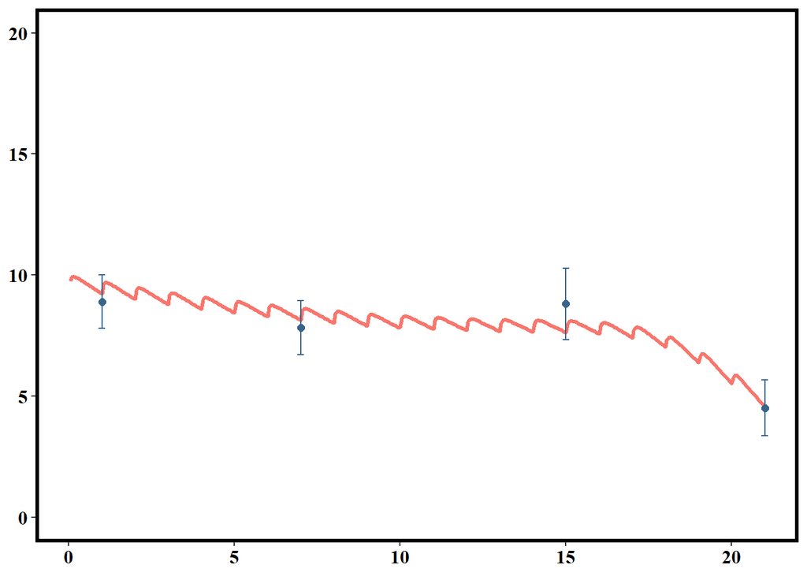

```r
## Add the font to font database
windowsFonts("Times" = windowsFont("Times New Roman"))

## Define the plot theme
PlotTheme <- theme (
  plot.background         = element_rect (fill="White"),
  text                    = element_text (family = "Times"),
  panel.border            = element_rect (colour = "black",
                                          fill = NA, size =   2),
  panel.background        = element_rect (fill="White"),
  panel.grid.major        = element_blank(),
  panel.grid.minor        = element_blank(),
  axis.text.x             = element_text (size   = 12,
                                          colour = "black", face = "bold"),
  axis.text.y             = element_text (size   = 12,
                                          colour = "black", face = "bold"),
  axis.title              = element_blank(),
  strip.background        = element_blank(),
  strip.text              = element_blank(),
  legend.position='none')

###### Plot

p1 <-
ggplot(data = out_0.1_G , aes(x = GD, y = CPlas)) +
geom_line    (aes(colour = Stage), size = 1.2) +
geom_point   (data   = obs_0.1 %>%filter(Stage == "G"),
              aes (x = GD, y = CPlas), colour = "steelblue4", size = 2)+
geom_errorbar(data = obs_0.1 %>%filter(Stage == "G"),
              aes(x = GD, ymin = CPlas-SD, ymax = CPlas+SD),
              colour = "steelblue4", width=.2,
              position=position_dodge(0.05)) +
              scale_x_continuous( expand = c (0, 0), limits = c(-1, 22)) +
              scale_y_continuous(limits = c(0, 20))


p2 <-
ggplot(data = out_0.4_L , aes(x = GD, y = CPlas)) +
geom_line  (colour = "steelblue3", size = 1.2) +
geom_point (data = obs_0.4%>%filter(Stage == "L"),
            aes (x = GD, y = CPlas), colour = "steelblue4", size = 2)+
geom_errorbar(data = obs_0.4%>%filter(Stage == "L"),
              aes(x = GD, ymin = CPlas-SD, ymax = CPlas+SD),
              colour = "steelblue4", width=.2,
              position=position_dodge(0.05)) +
              scale_x_continuous(expand = c (0,0), limits = c(0, 22)) +
              scale_y_continuous(limits = c(5, 50))


p3 <-
ggplot(data = out_0.8_L , aes(x = GD, y = CPlas_pup)) +
geom_line (colour = "grey", size = 1.2) +
geom_point (data = obs_0.8_pp %>%filter(Time>504),
            aes (x = GD-22, y = CPlas_pup),
            colour = "steelblue4", size = 2) +
geom_errorbar(data = obs_0.8_pp%>%filter(Time>504),
            aes(x = GD-22, ymin = CPlas_pup-SD, ymax = CPlas_pup+SD),
            colour = "steelblue4", width=.2,
            position=position_dodge(0.05)) +
            scale_x_continuous(expand = c (0,0), limits = c(0, 22)) +
            scale_y_continuous(limits = c(0, 150))

###############
p1 <- p1 + PlotTheme
p2 <- p2 + PlotTheme
p3 <- p3 + PlotTheme

p1 # Fig 3A : Comparisons of the model-predicted versus the observed PFOS levels in maternal plasma during gestation (maternal dose was 0.1 mg/kg/day as an example)
```

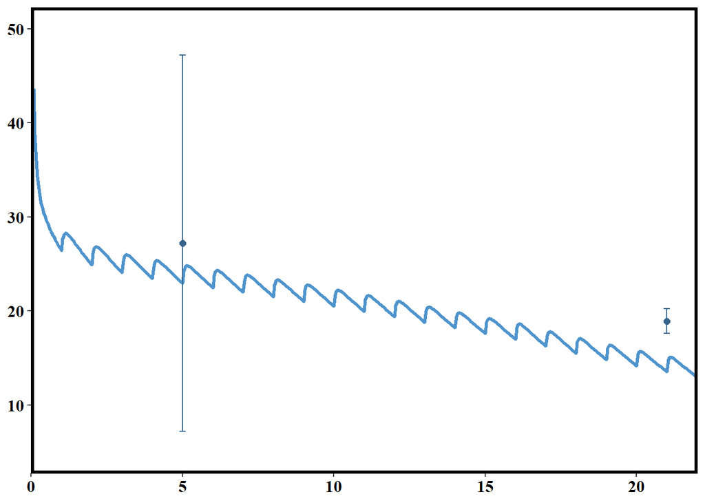

```r
p2 # Fig 3B : Comparisons of the model-predicted versus the observed PFOS levels in maternal plasma during lactation (maternal dose was 0.4 mg/kg/day as an example)
```

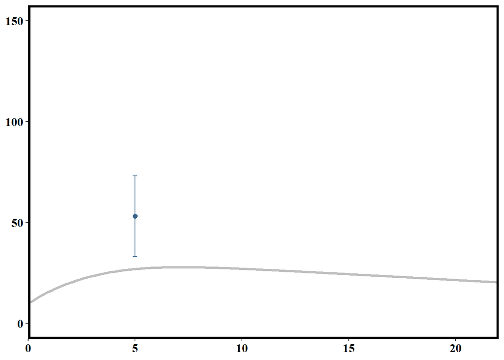

```r
p3 # Fig 3C : Comparisons of the model-predicted versus the observed PFOS levels in pup’s plasma in rats (maternal dose was 0.8 mg/kg/d as an example).
```

# Save the figure

Save your figures using `ggsave()`. In the `ggsave` function, you should set up the your path to save your figure in the local drive.

```r
# ggsave("Fig.3a.tiff",scale = 1,
#        plot = p1,
#        path = "C:/Users/weichunc/Desktop",
#        width = 9, height = 8, units = "cm", dpi=320)
#
# ggsave("Fig.3b.tiff",scale = 1,
#        plot = p2,
#        path = "C:/Users/weichunc/Desktop",
#        width = 9, height = 8, units = "cm", dpi=320)
#
# ggsave("Fig.3c.tiff",scale = 1,
#        plot = p3,
#        path = "C:/Users/weichunc/Desktop",
#        width = 9, height = 8, units = "cm", dpi=320)
```